# q_analysis() and simplicial_degree(): connectivity by overlap

honets

2026-08-26

## The analytic question

In a graph, two nodes are connected or they are not. In a simplicial complex there are *degrees* of connection: two groups might share one member, or three, or six. Q-analysis (Atkin 1974) takes that seriously.

Two simplices are **q-connected** when they share at least `q + 1` vertices, possibly through a chain of intermediates. Sweep `q` from high to low and you get a nested picture: at high `q` only heavily-overlapping groups are linked, and the structure fragments; as `q` falls, the fragments merge.

Where the merging happens tells you how the system is organised — something neither a degree distribution nor a Betti number reports.

```r
library(honets)
set.seed(1)
m <- matrix(runif(100), 10, 10)
m <- (m + t(m)) / 2
diag(m) <- 0
dimnames(m) <- list(LETTERS[1:10], LETTERS[1:10])
sc <- build_simplicial(m, type = "clique", threshold = 0.5)
```

## Running it

```r
qa <- q_analysis(sc)
qa
```

```
Q-Analysis (max q = 3)
  Components: q3:11 q2:10 q1:2 q0:1
  Fragments at q = 3 (11 components)
  Structure: A:3 C:3 D:3 E:3 I:3 B:2 F:2 G:2 H:2 J:2
```

## The q-vector

```r
as.data.frame(qa)
```

```
  q components
1 3         11
2 2         10
3 1          2
4 0          1
```

Read it from the top down. At `q = 3` — groups sharing four or more members — the complex is in **11 separate pieces**. At `q = 2` it is still 10. At `q = 1` it drops to 2, and at `q = 0` everything is a single component.

The collapse happens between `q = 2` and `q = 1`: this structure is held together by *pairwise* overlap, not by deep shared membership. Groups here touch each other lightly and rarely share three or more members. A system organised around tightly-interlocking teams would show the opposite profile — few components even at high `q`.

## Seeing the q-vector

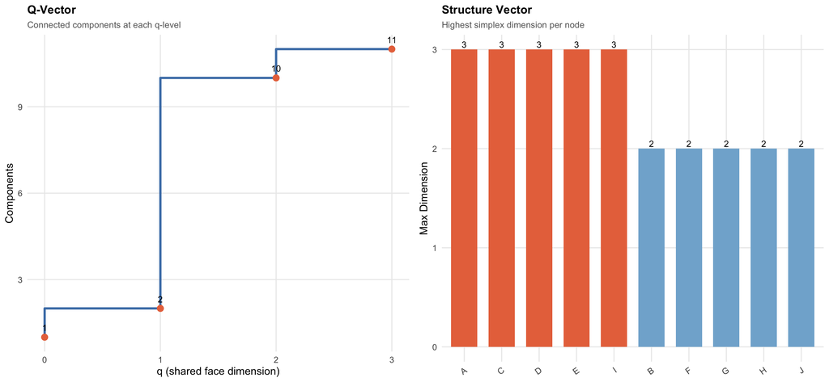

```r
plot(qa)
```

## Per-node structure

```r
as.data.frame(qa, what = "nodes")
```

```
   node max_q
1     A     3
2     B     2
3     C     3
4     D     3
5     E     3
6     F     2
7     G     2
8     H     2
9     I     3
10    J     2
```

`max_q` is the highest level at which each node still participates in a connected group. Nodes A, C, D, E and I reach `q = 3`; the rest stop at 2. Those five sit inside the most heavily-overlapping part of the complex.

## Simplicial degree

`simplicial_degree()` is the higher-order analogue of node degree: not “how many neighbours” but “how many groups of each size am I in?”

```r
simplicial_degree(sc)
```

```
   node d0 d1 d2 d3 total
5     E  1  6  7  2    15
1     A  1  6  6  2    14
9     I  1  5  6  2    13
4     D  1  5  6  1    12
7     G  1  5  4  0     9
10    J  1  5  4  0     9
2     B  1  5  3  0     8
8     H  1  4  4  0     8
3     C  1  3  3  1     7
6     F  1  4  2  0     6
```

`d0` is always 1 — every node is its own vertex. `d1` is ordinary graph degree. **`d2` and `d3` are where the higher-order information lives**: E is in 7 triangles and 2 tetrahedra, F in only 2 triangles and no tetrahedra, though their graph degrees (6 and 4) are not nearly so far apart.

The table is sorted by `total`, so the ranking is immediate.

### Ordinary degree does not predict it

```r
d <- simplicial_degree(sc)
data.frame(
  measure = c("d1 (graph degree) vs total", "d2 (triangles) vs total"),
  spearman = c(round(cor(d$d1, d$total, method = "spearman"), 3),
               round(cor(d$d2, d$total, method = "spearman"), 3))
)
```

```
                     measure spearman
1 d1 (graph degree) vs total    0.894
2    d2 (triangles) vs total    0.963
```

Graph degree correlates with higher-order degree, but imperfectly — the ranking by `total` is not the ranking by `d1`. A node can have many neighbours who are not connected to *each other*, which produces edges without triangles.

### Normalising

```r
simplicial_degree(sc, normalized = TRUE, top = 4)
```

```
  node d0        d1        d2         d3     total
1    E  1 0.6666667 0.1944444 0.02380952 0.8849206
2    A  1 0.6666667 0.1666667 0.02380952 0.8571429
3    I  1 0.5555556 0.1666667 0.02380952 0.7460317
4    D  1 0.5555556 0.1666667 0.01190476 0.7341270
```

`normalized = TRUE` divides each count by the maximum possible at that dimension, so values are comparable across dimensions and across complexes of different sizes. Use it when comparing datasets; use the raw counts when describing one.

## On real data

```r
seqs <- split(human_long$code, human_long$session_id)
sc_hon <- build_simplicial(build_hon(seqs, max_order = 3, min_freq = 5),
                           type = "pathway")
as.data.frame(q_analysis(sc_hon))
```

```
  q components
1 3         52
2 2         20
3 1          1
4 0          1
```

```r
simplicial_degree(sc_hon)
```

```
       node d0 d1 d2 d3 total
8   Specify  1  8 28 32    68
1   Command  1  8 28 19    55
7   Request  1  8 26 15    49
2   Correct  1  8 26 12    46
3 Frustrate  1  8 26 12    46
4   Inquire  1  8 25 13    46
6    Refine  1  8 27 11    46
5 Interrupt  1  8 26 10    44
9    Verify  1  8 25  8    41
```

When `d1` is constant, ordinary degree centrality is uninformative by construction, and the higher-order degree is the only thing distinguishing the nodes.

## What to do next

- **`betti_numbers()`** — holes rather than overlap; the other topological summary of the same complex.
- **`build_simplicial()`** — how the complex is built, and how sensitive it is to `threshold`.
- **`hypergraph_measures()`** — overlap statistics without the subset-closure assumption.

## References

- Atkin, R. H. (1974). *Mathematical Structure in Human Affairs*. Heinemann.
- Johnson, J. (2013). *Hypernetworks in the Science of Complex Systems*. Imperial College Press.
- Estrada, E., & Ross, G. J. (2018). Centralities in simplicial complexes. *Journal of Theoretical Biology*, 438, 46-60.